# Biostat 203B Homework 4

Due Mar 18 @ 11:59PM

Load database libraries and the tidyverse frontend:

```r
suppressPackageStartupMessages(library(tidyverse))
suppressPackageStartupMessages(library(lubridate))
suppressPackageStartupMessages(library(miceRanger))
```

## Q1. Missing data

Through the Shiny app developed in HW3, we observe abundant missing values in the MIMIC-IV ICU cohort we created. In this question, we use multiple imputation to obtain a data set without missing values.

0. Read following tutorials on the R package miceRanger for imputation: https://github.com/farrellday/miceRanger, https://cran.r-project.org/web/packages/miceRanger/vignettes/miceAlgorithm.html.

   A more thorough book treatment of the practical imputation strategies is the book [*Flexible Imputation of Missing Data*](https://stefvanbuuren.name/fimd/) by Stef van Buuren.
1. Explain the jargon MCAR, MAR, and MNAR.

MCAR (Missing Completely at Random) -> probability of the data being missing is same for all cases. There is a known reason that some of the data is missing. Most of the time, such missing data is caused by improper measurement or just good-old bad luck.

MAR (Missing at Random) -> probability of data being missing is the same within the same category of data. If a certain measurement technique / tool is known to have given you more missing data, then those missing data are considered MAR. It is the more realistic category of missing data compared to MCAR. Essentially, there’s somewhat an underlying reason why there is a missing data - that happened in during the data measurement.

MNAR (Missing not at Random) -> when we have no idea why the data is missing. This is a type of missing data that doesn’t fall under MCAR or MAR.

2. Explain in a couple of sentences how the Multiple Imputation by Chained Equations (MICE) work.

The MICE algorithm is capable of filling in missing data on multiple variables. It starts by filling in the missing data with random values. Then, a random forest is performed to predict the missing values of one variable using the rest of the other variables. Keep in mind that the rest of the other variables, at this point, is still randomly filled (within a reasonable range depending on the variable’s distribution).

Now that we’ve got the imputed values for the first variable, it is time to impute the second variable again, using random forest on data from the first variable (that has been imputed) and the rest of the variables. We would then keep repeating this step until it converges. Typically, MICE will take no more than 5 iterations.

3. Perform a data quality check of the ICU stays data. Discard variables with substantial missingness, say >5000 `NA`s. Replace apparent data entry errors by `NA`s.

```r
mimic_icu_cohort <- readRDS("icu_cohort_log.rds") %>%
  print(width = Inf)
```

```
## # A tibble: 53,065 × 43
##    subject_id  hadm_id  stay_id first_careunit
##         <dbl>    <dbl>    <dbl> <chr>
##  1   18106347 24305596 30588857 Cardiac Vascular Intensive Care Unit (CVICU)
##  2   17195991 23542772 38319097 Surgical Intensive Care Unit (SICU)
##  3   16284044 23864737 36817845 Cardiac Vascular Intensive Care Unit (CVICU)
##  4   18122666 23883987 39753527 Medical/Surgical Intensive Care Unit (MICU/SICU)
##  5   18780420 28977824 32140208 Neuro Surgical Intensive Care Unit (Neuro SICU)
##  6   15092543 28768907 38339174 Neuro Intermediate
##  7   13201095 28453791 39953418 Coronary Care Unit (CCU)
##  8   12770182 20446666 34901199 Medical Intensive Care Unit (MICU)
##  9   12224263 23294937 37546608 Trauma SICU (TSICU)
## 10   19564586 22461053 37310703 Coronary Care Unit (CCU)
##    last_careunit                                    intime
##    <chr>                                            <dttm>
```

[output cut: 107 more lines]

Create a summary to observe which columns have >5000 NAs. Turns out these variables have >5000 NAs: `dod deathtime edregtime edouttime`

```r
summary(mimic_icu_cohort)
```

```
##    subject_id          hadm_id            stay_id         first_careunit
##  Min.   :10000032   Min.   :20000094   Min.   :30000153   Length:53065
##  1st Qu.:12483898   1st Qu.:22478093   1st Qu.:32467111   Class :character
##  Median :14991424   Median :24947644   Median :34987214   Mode  :character
##  Mean   :14989837   Mean   :24975852   Mean   :34984050
##  3rd Qu.:17495811   3rd Qu.:27477277   3rd Qu.:37487113
##  Max.   :19999987   Max.   :29999828   Max.   :39999810
##
##  last_careunit          intime                       outtime
##  Length:53065       Min.   :2110-01-11 10:16:06   Min.   :2110-01-12 17:17:47
##  Class :character   1st Qu.:2132-11-05 21:29:00   1st Qu.:2132-11-07 16:56:01
##  Mode  :character   Median :2152-09-29 21:13:55   Median :2152-10-03 19:16:01
##                     Mean   :2152-10-28 03:05:41   Mean   :2152-10-31 11:49:07
##                     3rd Qu.:2172-11-04 17:18:32   3rd Qu.:2172-11-06 10:29:59
##                     Max.   :2211-05-01 06:59:19   Max.   :2211-05-10 22:51:06
##
##       los               gender            anchor_age     anchor_year
##  Min.   :  0.00125   Length:53065       Min.   :18.00   Min.   :2109
##  1st Qu.:  1.08575   Class :character   1st Qu.:53.00   1st Qu.:2131
##  Median :  1.87755   Mode  :character   Median :65.00   Median :2151
##  Mean   :  3.36349                      Mean   :63.59   Mean   :2151
##  3rd Qu.:  3.54231                      3rd Qu.:77.00   3rd Qu.:2171
##  Max.   :110.23228                      Max.   :91.00   Max.   :2207
##
##  anchor_year_group       dod               admittime
##  Length:53065       Min.   :2110-01-25   Min.   :2110-01-11 10:14:00
##  Class :character   1st Qu.:2133-04-27   1st Qu.:2132-11-03 21:46:00
##  Mode  :character   Median :2153-02-22   Median :2152-09-28 20:40:00
##                     Mean   :2153-06-19   Mean   :2152-10-27 02:08:14
##                     3rd Qu.:2173-09-21   3rd Qu.:2172-11-04 12:57:00
##                     Max.   :2211-01-17   Max.   :2211-05-01 06:57:00
##                     NA's   :45148
##    dischtime                     deathtime                   admission_type
##  Min.   :2110-01-15 17:31:00   Min.   :2110-01-25 09:40:00   Length:53065
##  1st Qu.:2132-11-14 16:40:00   1st Qu.:2132-07-10 07:00:00   Class :character
##  Median :2152-10-07 17:00:00   Median :2152-02-27 00:01:00   Mode  :character
##  Mean   :2152-11-05 12:22:14   Mean   :2152-05-26 08:36:13
##  3rd Qu.:2172-11-10 14:55:00   3rd Qu.:2172-05-05 03:35:00
##  Max.   :2211-05-12 17:54:00   Max.   :2211-01-17 12:34:00
##                                NA's   :47558
```

[output cut: 49 more lines]

```
##  Min.   :     0.0     Min.   :  0.00   Min.   :  0.00   Min.   : 19.00
##  1st Qu.:    70.0     1st Qu.: 15.00   1st Qu.: 97.60   1st Qu.: 54.00
##  Median :    81.0     Median : 18.00   Median : 98.10   Median : 66.00
##  Mean   :    87.4     Mean   : 18.69   Mean   : 98.03   Mean   : 64.54
##  3rd Qu.:    93.0     3rd Qu.: 22.00   3rd Qu.: 98.70   3rd Qu.: 78.00
##  Max.   :140119.0     Max.   :180.00   Max.   :106.00   Max.   :102.00
##  NA's   :533          NA's   :37       NA's   :819
##  thirty_days_mort
##  Mode :logical
##  FALSE:47855
##  TRUE :5210
##
##
##
##
```

Exclude columns with >5000 NAs

```r
mimic_icu_cohort <- mimic_icu_cohort %>%
  select(-dod, -deathtime, -edregtime, -edouttime) %>%
  print(width = Inf)
```

```
## # A tibble: 53,065 × 39
##    subject_id  hadm_id  stay_id first_careunit
##         <dbl>    <dbl>    <dbl> <chr>
##  1   18106347 24305596 30588857 Cardiac Vascular Intensive Care Unit (CVICU)
##  2   17195991 23542772 38319097 Surgical Intensive Care Unit (SICU)
##  3   16284044 23864737 36817845 Cardiac Vascular Intensive Care Unit (CVICU)
##  4   18122666 23883987 39753527 Medical/Surgical Intensive Care Unit (MICU/SICU)
##  5   18780420 28977824 32140208 Neuro Surgical Intensive Care Unit (Neuro SICU)
##  6   15092543 28768907 38339174 Neuro Intermediate
##  7   13201095 28453791 39953418 Coronary Care Unit (CCU)
##  8   12770182 20446666 34901199 Medical Intensive Care Unit (MICU)
##  9   12224263 23294937 37546608 Trauma SICU (TSICU)
## 10   19564586 22461053 37310703 Coronary Care Unit (CCU)
##    last_careunit                                    intime
##    <chr>                                            <dttm>
```

[output cut: 95 more lines]

Replace outliers with NAs, then use `summary()` to check whether outlier has been removed.

```r
outlierToNa <- function(x) {
  Q1 <- quantile(x, .25, na.rm = TRUE)
  Q3 <- quantile(x, .75, na.rm = TRUE)
  IQR <- Q3 - Q1
  x[x < (Q1 - 1.5*IQR) | x > (Q3 + 1.5*IQR)] <- NA
  x
}

measurements <- select(mimic_icu_cohort, c(23:37))

modified_measurements <- measurements %>%
  mutate_all(outlierToNa)

summary(modified_measurements)
```

```
##   bicarbonate      calcium          chloride       creatinine       glucose
##  Min.   :15.0   Min.   : 6.400   Min.   : 91.0   Min.   :0.000   Min.   : 24
##  1st Qu.:21.0   1st Qu.: 7.900   1st Qu.:101.0   1st Qu.:0.700   1st Qu.:101
##  Median :23.0   Median : 8.400   Median :105.0   Median :0.900   Median :120
##  Mean   :23.1   Mean   : 8.373   Mean   :104.8   Mean   :0.956   Mean   :127
##  3rd Qu.:25.0   3rd Qu.: 8.800   3rd Qu.:108.0   3rd Qu.:1.100   3rd Qu.:147
##  Max.   :31.0   Max.   :10.400   Max.   :118.0   Max.   :2.200   Max.   :235
##  NA's   :3934   NA's   :3009     NA's   :2516    NA's   :5711    NA's   :4320
##    magnesium       potassium         sodium        hematocrit      wbc_count
##  Min.   :1.000   Min.   :2.600   Min.   :129.0   Min.   :14.40   Min.   : 0.0
##  1st Qu.:1.700   1st Qu.:3.700   1st Qu.:136.0   1st Qu.:28.10   1st Qu.: 7.4
##  Median :1.900   Median :4.100   Median :139.0   Median :32.70   Median :10.2
##  Mean   :1.959   Mean   :4.109   Mean   :138.7   Mean   :32.73   Mean   :10.9
##  3rd Qu.:2.200   3rd Qu.:4.500   3rd Qu.:141.0   3rd Qu.:37.20   3rd Qu.:13.8
##  Max.   :2.900   Max.   :5.600   Max.   :148.0   Max.   :51.00   Max.   :24.6
##  NA's   :2561    NA's   :2621    NA's   :3060    NA's   :1143    NA's   :2975
##    heart_rate     systolic_non_invasive_bp mean_non_invasive_bp   resp_rate
##  Min.   : 37.00   Min.   : 57.0            Min.   : 36.00       Min.   : 5.00
##  1st Qu.: 74.00   1st Qu.:106.0            1st Qu.: 70.00       1st Qu.:15.00
##  Median : 85.00   Median :122.0            Median : 80.00       Median :18.00
##  Mean   : 86.49   Mean   :122.9            Mean   : 81.49       Mean   :18.23
##  3rd Qu.: 98.00   3rd Qu.:139.0            3rd Qu.: 92.00       3rd Qu.:21.00
##  Max.   :136.00   Max.   :188.0            Max.   :127.00       Max.   :32.00
##  NA's   :972      NA's   :1094             NA's   :1515         NA's   :1660
##    body_temp
##  Min.   : 96.00
##  1st Qu.: 97.70
##  Median : 98.10
##  Mean   : 98.15
##  3rd Qu.: 98.60
##  Max.   :100.30
##  NA's   :4759
```

Prepare data for imputation to only include necessary variables (specifically, I only include lab measurements, chart measurements, age of patients, gender, marital status, ethnicity, and 30daysmort).

```r
tbi <- select(mimic_icu_cohort, c( 'gender','age_hadm','marital_status',
                                   'ethnicity','thirty_days_mort'))
tbi <- bind_cols(tbi, modified_measurements)
#summary(tbi)
print(tbi, width = Inf)
```

```
## # A tibble: 53,065 × 20
##    gender age_hadm marital_status ethnicity        thirty_days_mort bicarbonate
##    <chr>     <dbl> <chr>          <chr>            <lgl>                  <dbl>
##  1 F            48 DIVORCED       WHITE            FALSE                     24
##  2 F            61 SINGLE         UNABLE TO OBTAIN FALSE                     23
##  3 F            61 DIVORCED       WHITE            FALSE                     22
##  4 M            60 DIVORCED       WHITE            FALSE                     24
##  5 M            84 MARRIED        WHITE            FALSE                     22
##  6 F            74 WIDOWED        WHITE            FALSE                     NA
##  7 F            88 WIDOWED        UNKNOWN          TRUE                      24
##  8 M            53 MARRIED        WHITE            FALSE                     28
##  9 F            52 MARRIED        OTHER            FALSE                     NA
## 10 M            64 DIVORCED       WHITE            FALSE                     21
##    calcium chloride creatinine glucose magnesium potassium sodium hematocrit
##      <dbl>    <dbl>      <dbl>   <dbl>     <dbl>     <dbl>  <dbl>      <dbl>
```

[output cut: 35 more lines]

4. Impute missing values by `miceRanger` (request $m=3$ data sets). This step is computational intensive. Make sure to save the imputation results as a file. Hint: Setting `max.depth=10` in the `miceRanger` function may cut some computing time.

**Answer** I’m setting the cell below to `eval=F` because running `miceRanger()` will take forever to knit.

```r
seqTime <- system.time(
  imputedObj <- miceRanger(
    tbi,
    m = 3,
    returnModels = FALSE, #False is better here due to file size
    verbose = FALSE,
    max.depth = 10
  )
)
saveRDS(imputedObj, "very_newest_imputation_result")
```

```r
imputedObj <- readRDS("very_newest_imputation_result")
```

5. Make imputation diagnostic plots and explain what they mean.

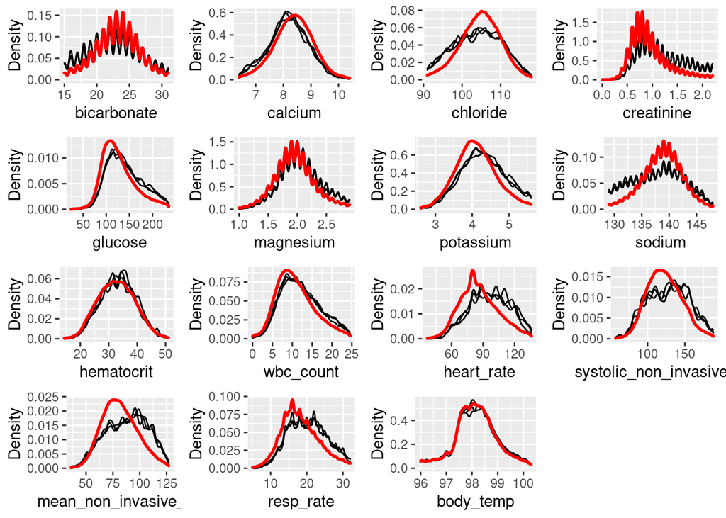

```r
plotDistributions(imputedObj, vars = 'allNumeric')
```

This diagnostic plot tells us the accuracy of classification and r-squared regression.

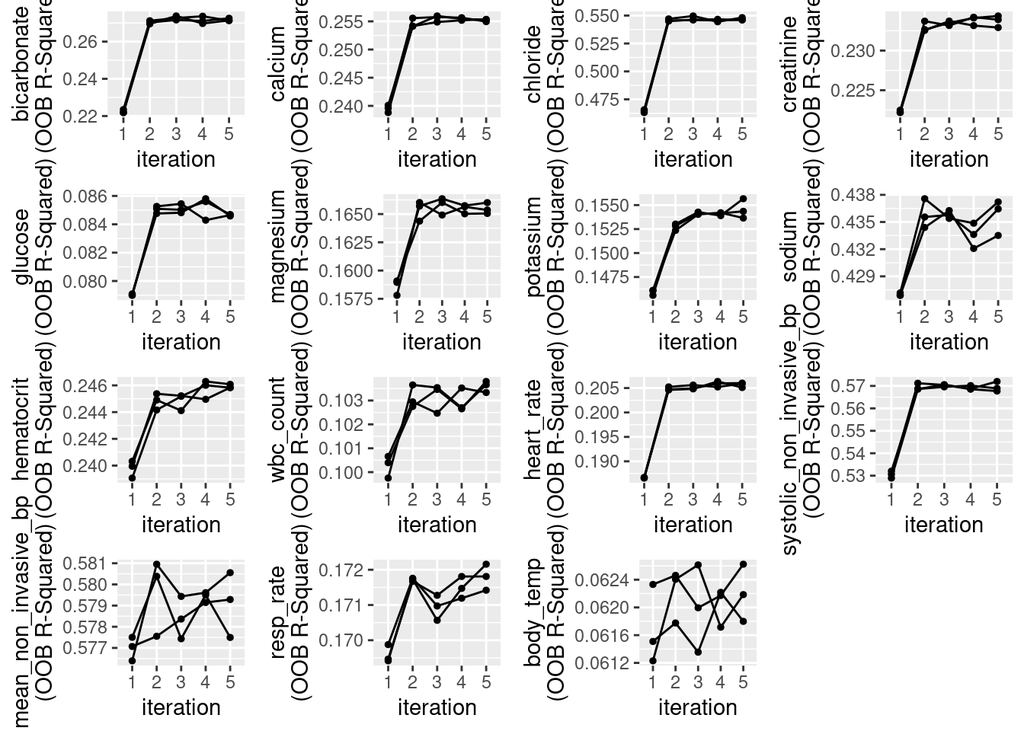

```r
plotModelError(imputedObj, vars = 'allNumeric')
```

6. Choose one of the imputed data sets to be used in Q2. This is **not** a good idea to use just one imputed data set or to average multiple imputed data sets. Explain in a couple of sentences what the correct Multiple Imputation strategy is.

To get the imputed data, we need to use `completeData`

```r
imp_icustays_tble <- completeData(imputedObj)
```

## Q2. Predicting 30-day mortality

Develop at least two analytic approaches for predicting the 30-day mortality of patients admitted to ICU using demographic information (gender, age, marital status, ethnicity), first lab measurements during ICU stay, and first vital measurements during ICU stay. For example, you can use (1) logistic regression (`glm()` function in base R or keras), (2) logistic regression with lasso penalty (glmnet or keras package), (3) random forest (randomForest package), or (4) neural network (keras package).

1. Partition data into 80% training set and 20% test set. Stratify partitioning according the 30-day mortality status.

```r
suppressPackageStartupMessages(library(caret))
```

```r
icu_dataset = imp_icustays_tble$Dataset_1
#Convert boolean to int 0 1
icu_dataset$thirty_days_mort_int <- as.integer(icu_dataset$thirty_days_mort)
icu_dataset <- select(icu_dataset, -thirty_days_mort)

trainIndex <- createDataPartition(icu_dataset$thirty_days_mort_int, p = .8,
                                  list = FALSE,
                                  times = 1)
icu_train <- icu_dataset[trainIndex,]
icu_test <- icu_dataset[-trainIndex,]
```

2. Train the models using the training set.

First, train it with the base R logistic regression, `glm()`

```r
logistic_model <- glm(thirty_days_mort_int ~ ., icu_train, family = binomial)
#summary(logistic)
```

Now, train it with penalized regression using `glmnet()`

```r
library(glmnet)
x <- model.matrix(thirty_days_mort_int ~ ., icu_train)
y <- icu_train$thirty_days_mort_int
penalized_logistic_model <- cv.glmnet(x, y, family = 'binomial', alpha = 1)
```

3. Compare model prediction performance on the test set.

The accuracy for logistic regression: `glm()`

```r
pred_log <- predict(logistic_model, icu_test, type = "response")
prediction_log <- ifelse(pred_log < 0.5, 0, 1)
mean(prediction_log == icu_test$thirty_days_mort_int)
```

```
## [1] 0.9004994
```

The accuracy for logistic regression with LASSO penalty: `glmnet()`

```r
test_x <- model.matrix(icu_test$thirty_days_mort_int ~ ., icu_test)
pred <- predict(penalized_logistic_model, newx = test_x, s = 1, type = "response")
#With a threshold of 0.5, convert the prediction probability to 0 and 1
prediction <- ifelse(pred < 0.5, 0, 1)
mean(prediction == icu_test$thirty_days_mort_int)
```

```
## [1] 0.8975784
```

When comparing the two performance, we can see that the accuracy for logistic regression with LASSO penalty is a little bit worse than logistic regression in this case. They are still very fairly comparable as they are usually both around 90% accurate. The numbers are different everytime simply because we are splitting the training/testing set at ‘random’, so the performance will be different every run.